# Understanding how floods in Emilia-Romagna shaped micro-level socio-political narratives

This notebook and slide deck showcase the key insights derived from the survey responses collected through the survey questionnaire prepared for this research. The survey questionnaire (Italian | English) is coded and distributed through Qualtrics platform. Survey responses are exported and downloaded to this repository to present key insights through data visualizations.

The survey aims to gather information on the attributes of the Narrative Policy Framework (NPF), including the Hero, Villain, Victim, and Moral of the Story. Traditionally, extracting these attributes relied on analyzing long-format textual data. However, previous approaches using open ended text-based questions often resulted in a high survey dropout rate.

To address this issue, the survey employs multiple-choice questions instead of open-ended text questions to infer these narrative components. By utilizing this approach, the survey aims to improve respondent engagement and completion rates.

The attributes identified through the NPF will later be compared and integrated with the attributes of macro-narratives of floods collected from newspaper articles in the subsequent stages of this research.

**Table of contents**

- Survey Results
  - Read and prepare data for analysis
    - Cleaning data by removing incomplete responses
  - Meta data
    - Survey duration
  - Demographics data
  - Source of information for respondents
  - Questions related to May 2023 Floods of Emilia-Romagna
  - Hero, Villain, and Victim
    - Villain
    - Victim
    - Hero
    - Moral of the story: Policy Solution
  - General questions about climate change

## Read and prepare data for analysis

The data exported by Qualtrics is downloaded and stored on the data folder of this GitHub repository. All the data cleaning and data preparation processes are performed in the same notebook.

*Scroll down to see at what point users dropped out of the survey.*

### Cleaning data by removing incomplete responses

Survey responses are cleaned by removing incomplete entries along with responses that failed the attention test.

| Description | Node |
| --- | --- |
| Started Survey (624) | 624 |
| Not a Resident | 6 |
| Failed Attention Test 1 | 56 |
| Failed Attention Test 2 | 57 |
| Dropped Out | 5 |
| Finished Survey (500) | 500 |

[figure not shown]

## Meta data

This section contains plot of survey duration and results of screening questions regarding geographic location of responders.

*Scroll down to see plots regarding to survey duration and geographic location of responders.*

### Survey duration

Following plot shows the average time taken to complete the survey.

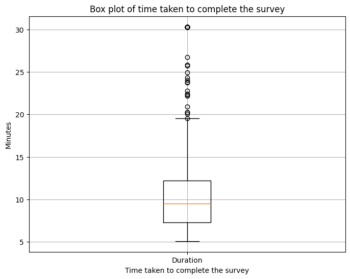

The above plot depicts the time taken to complete the survey questionnaire. At least 25% of respondents spent more than 7 minutes with the survey questionnaire. Most users took around 9 minutes to complete the survey questionnaire.

How long have you lived in Emilia-Romagna?

```
Q4 Da quanto tempo vive in Emilia-Romagna?

* Meno di 5 anni
* 5 - 10 anni
* 10 - 15 anni
* 15 - 20 anni
* Più di 20 anni
```

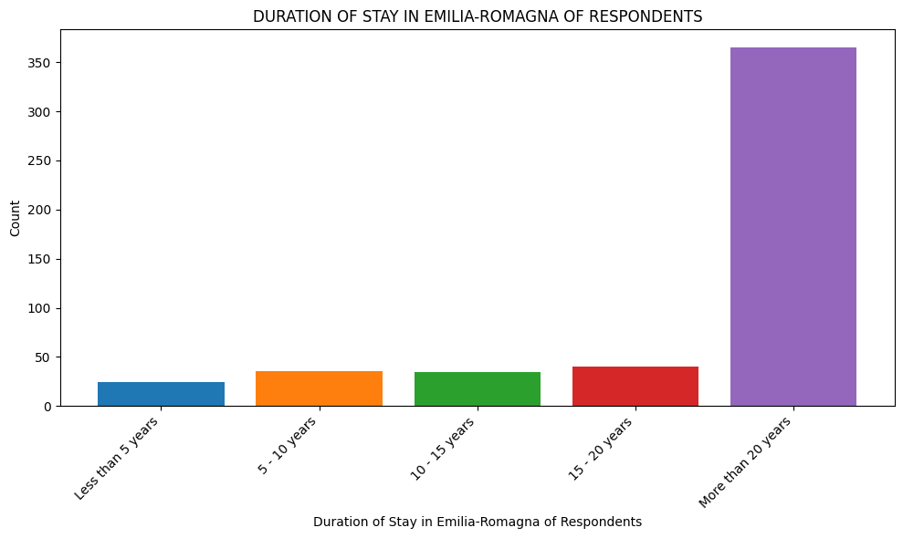

All the respondents are filtered based on their location. Only residents of Emilia-Romagna are allowed to continue the survey. More than 70 percentage of residents are living in Emilia-Romagna for more than 20 years.

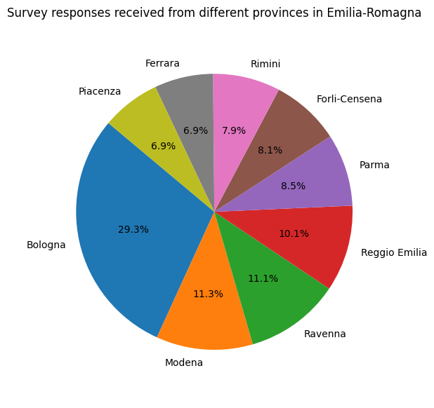

30% of respondents are from Bologna. Approximately 10% of respondents are from each province of Modena, Ravenna, and Reggio Emilia. Following closely are Parma, Rimini, and Forlì-Cesena, each representing around 8% of the respondents. Finally, around 7% of the respondents hail from Ferrara and Piacenza, respectively.

## Demographics data

Following charts showcase the demographic details of respondents that filled up the survey questionnaire.

*Scroll down to see demographic insights.*

Select the highest level of education achieved.

```
    Q34 Selezionare il livello di istruzione più alto raggiunto.

    *	Scuola primaria
    *	Scuole medie
    *	Scuole superiori
    *	Laurea o superiore
```

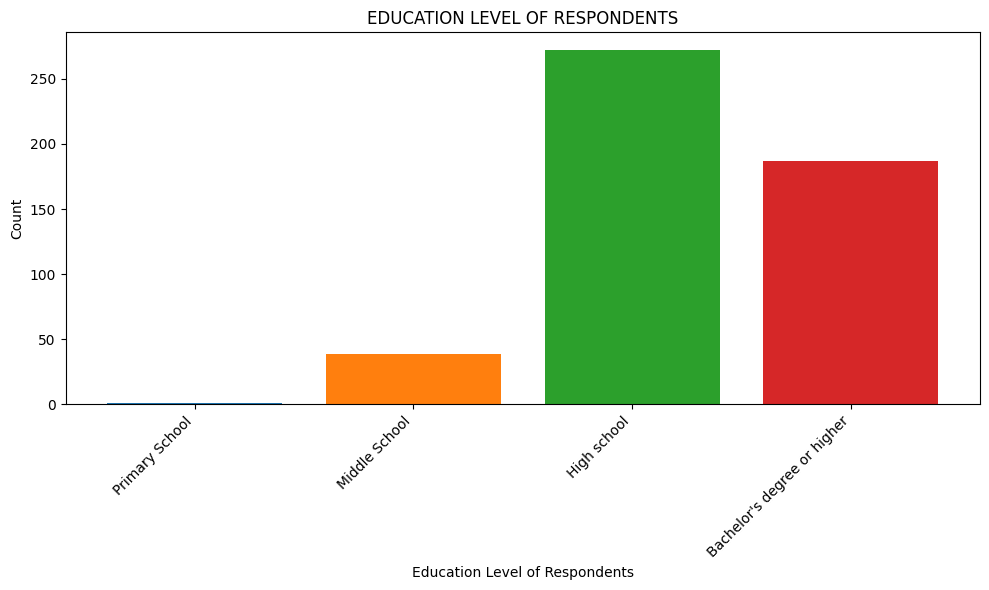

More than 50 percent of respondents were at the high school level of education. 187 respondents hold a bachelor's degree or higher education level. Only 39 respondents were at the middle school level of education, and only one respondent was at the primary school level of education.

Select your gender.

```
    Q35 Selezionare il proprio sesso.

    *	Uomo
    *	Donna
    *	Non binario / terzo genere
    *   Preferisco non dirlo
```

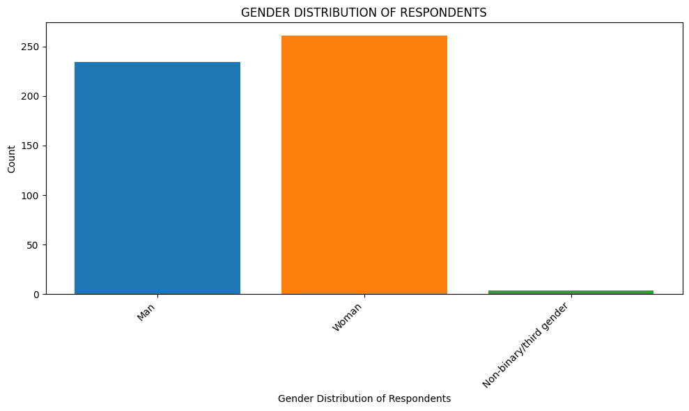

The gender balance of respondents is equal. The respondent group comprises 261 women, 234 men, and four non-binary individuals.

What is your age?

```
    Q36 Qual è la sua età?

    *	Meno di 18
    *	18 - 24
    *	25 - 34
    *	35 - 44
    *	45 - 54
    *	55 - 64
    *	65 anni o più
```

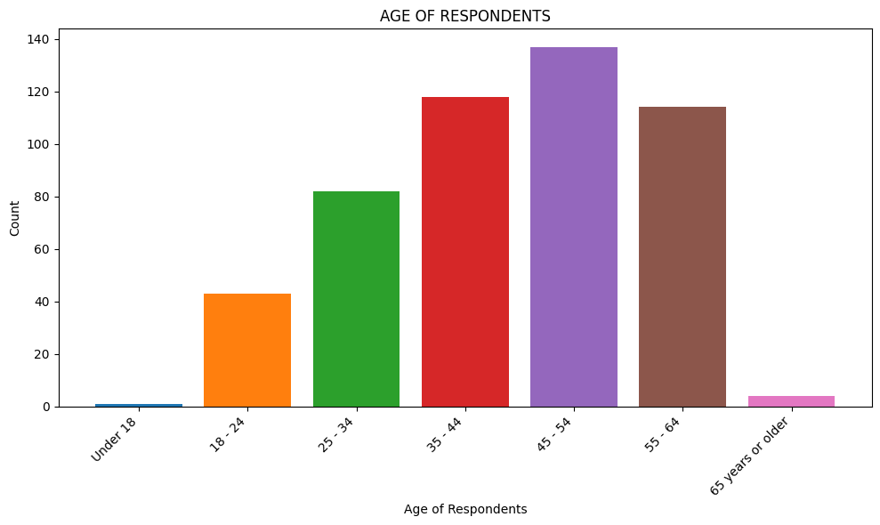

Over 70 percent of respondents are over the age of 35. The largest demographic, totaling 137 respondents, falls within the age group of 45-54 years, followed by 118 and 114 respondents in the age brackets of 35-44 years and 55-64 years, respectively. On the younger end of the spectrum, 82 respondents are aged 25-34, and 43 respondents fall between the ages of 18-24. Additionally, four respondents are over 65 years old.

How many people live in your household, including you?

```
    Q37 Quante persone vivono nel suo nucleo familiare, lei compreso?

    *	1 persona
    *	2 persone
    *	3-4 persone
    *	5 o più
```

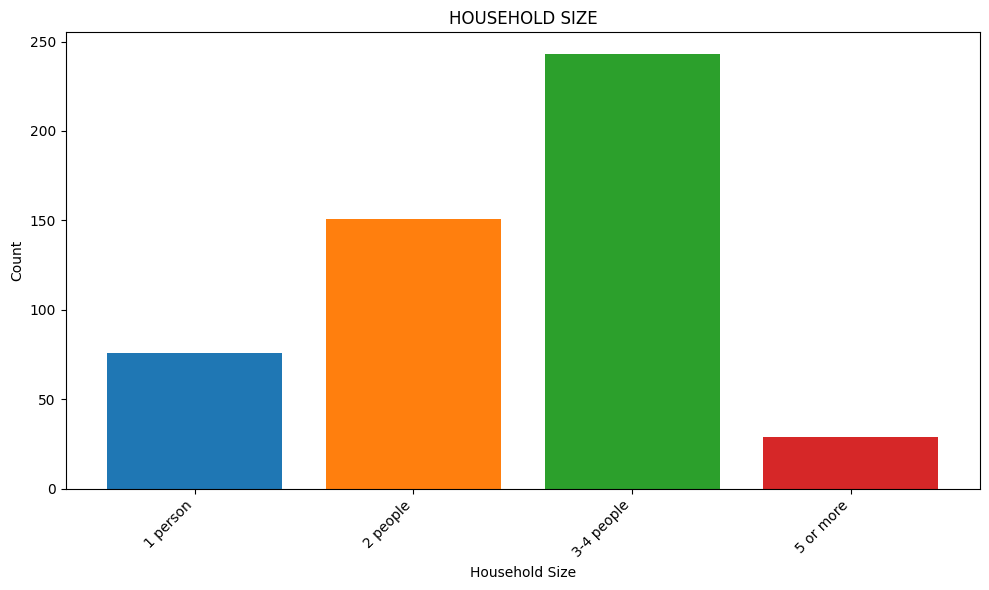

Which of the following descriptions is closest to your work situation?

```
    Q38 Quale delle seguenti descrizioni è piú vicina alla sua situazione lavorativa?

    *	Sono uno studente
    *	Sono un imprenditore o un lavoratore autonomo
    *	Sono impiegato
    *	Cerco un'opportunità di lavoro
    *	Non sto lavorando e non ho intenzione di trovare un lavoro nel prossimo futuro
    *	Sono in pensione
```

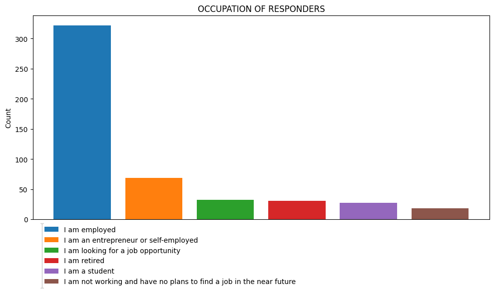

More than 50 percent of respondents are employed. Apart from them, 69 respondents are either entrepreneurs or self-employed, while 27 are students. Additionally, 32 respondents are actively seeking job opportunities, and 31 respondents are retired. On the other hand, 18 respondents are neither working nor pursuing any future opportunities.

What is your sector of work or activity?

```
    Q39 Qual è il suo settore di lavoro o di attività?

    *	Industria delle materie prime (agricoltura, miniere, ecc.)
    *	Industria manifatturiera
    *	Servizi
    *	Settore della conoscenza o dell'istruzione
    *	Settore pubblico
```

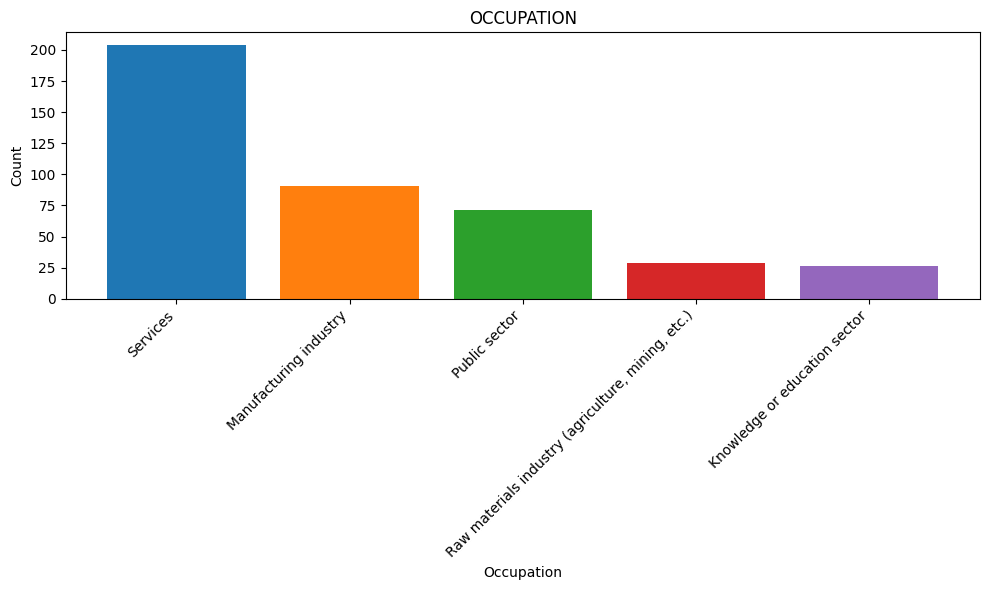

Among those employed or owning a business, over 50 percent work in the private sector, with 91 respondents employed in the manufacturing industry and 71 in the public sector. A smaller minority, consisting of 29 and 26 respondents respectively, are employed in the primary sector and knowledge sector.

When looking for a new job, do you consider the environmental impact of your potential employer?

```
    Q40 Mentre cerca un nuovo lavoro, considera l'impatto ambientale del suo potenziale datore  di lavoro?

    *	Decisamente sì   (1)
    *	Abbastanza  (2)
    *	Non necessariamente  (3)
    *	Decisamente no  (4)
```

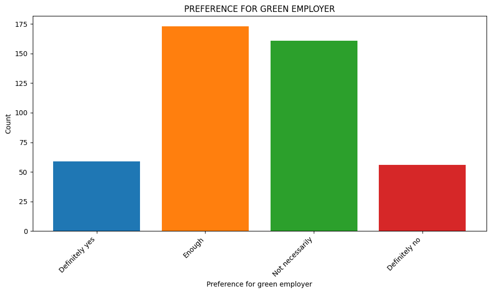

What is your household's net annual income?

```
    Q41 Qual è il reddito annuo netto del suo nucleo familiare?

    *	Meno di €15.000  (1)
    *	Tra €15.000 e €28.000  (2)
    *	Tra €28.000 e €50.000  (3)
    *	Tra €50.000 e €80.000  (4)
    *	€80.000 o più  (5)
```

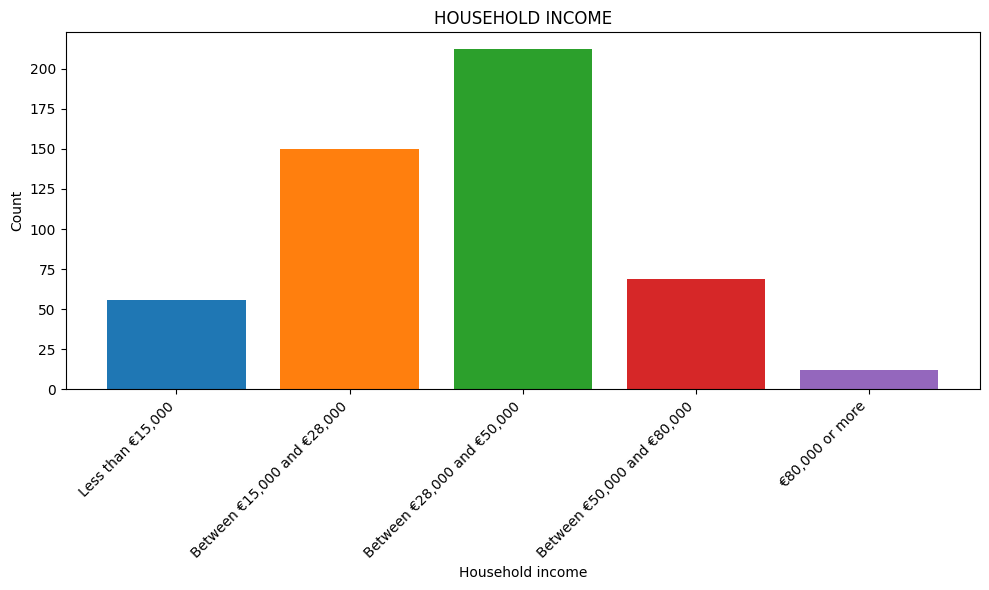

Approximately what percentage of the monthly household income is spent on the electricity bill?

```
    Q43 Approssimativamente, quale percentuale del reddito familiare mensile è speso per la bolletta elettrica?

    *	meno del 10%
    *	11% - 20%
    *	21% - 30%
    *	31% - 40%
    *	41% o superiore
```

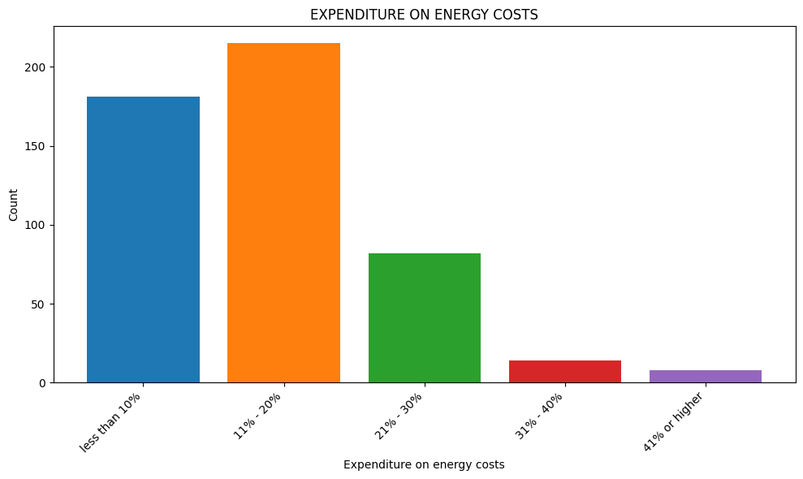

How many times a month do you refuel your vehicle?

```
    Q44 Quante volte al mese fa rifornimento di carburante al suo veicolo?

    *	Al massimo una volta al mese
    *	Due o tre volte al mese
    *	Quattro o cinque volte al mese
    *	Più di sei volte al mese
    *	Ho un'auto elettrica
    *	Non ho un'auto
```

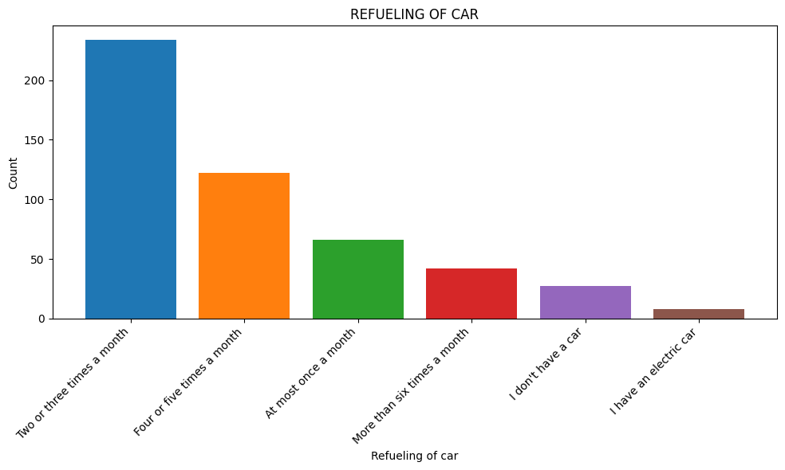

How often do you consume meat in your family?

```
    Q45 Con quale frequenza consuma carne nella sua famiglia?

    *	Mai
    *	Una volta alla settimana
    *	Da due a quattro volte alla settimana
    *	Ogni giorno
```

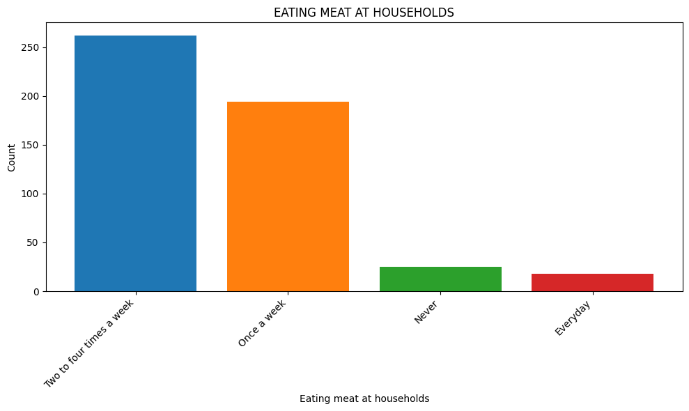

## Source of information for respondents

Opinions of respondents are largely shaped by the information and narratives provided to them through their sources of information. Therefore, the following questions aim to identify their primary sources of information, as well as their preferred news channels and newspapers.

*Scroll down to see insights on source of information of respondents*

What is your primary source of news and information?

```
    Q31 Qual è la sua fonte primaria di notizie e informazioni?

    *	Giornali (cartacei o online)
    *	Social media (Facebook, Twitter, YouTube, etc.)
    *	Amici e circolo sociale
    *	Canali televisivi (su TV o Internet)
    *	Altro (specificare)
```

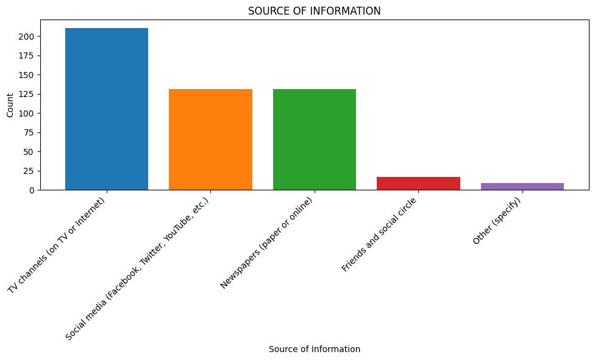

Which news channel do you watch the most?

```
    Q32 Quale Telegiornale guarda di più?

    *	Rai 1 o Rai 2
    *	Mediaset
    *	La 7
    *	Rai 3
    *	Sky TG24
    *	Un altro canale (specificare)
```

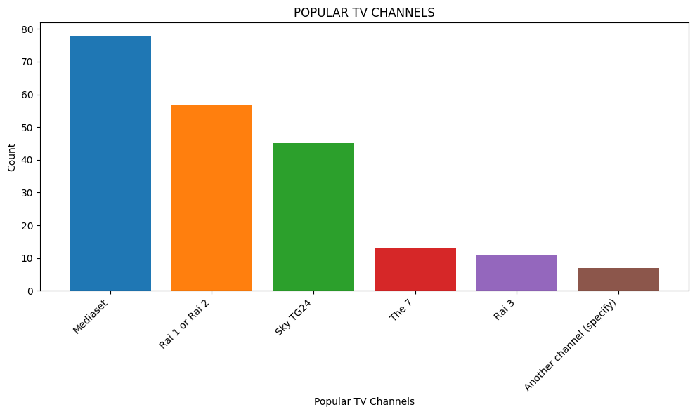

Which newspaper do you read the most? (Paper or digital)

```
    Q33 Quale giornale legge di più? (Cartaceo o digitale)

    *	Il Corriere della Sera
    *	La Repubblica
    *	Il Sole 24 Ore
    *	Il Resto del Carlino
    *	Un altro giornale (specificare)
```

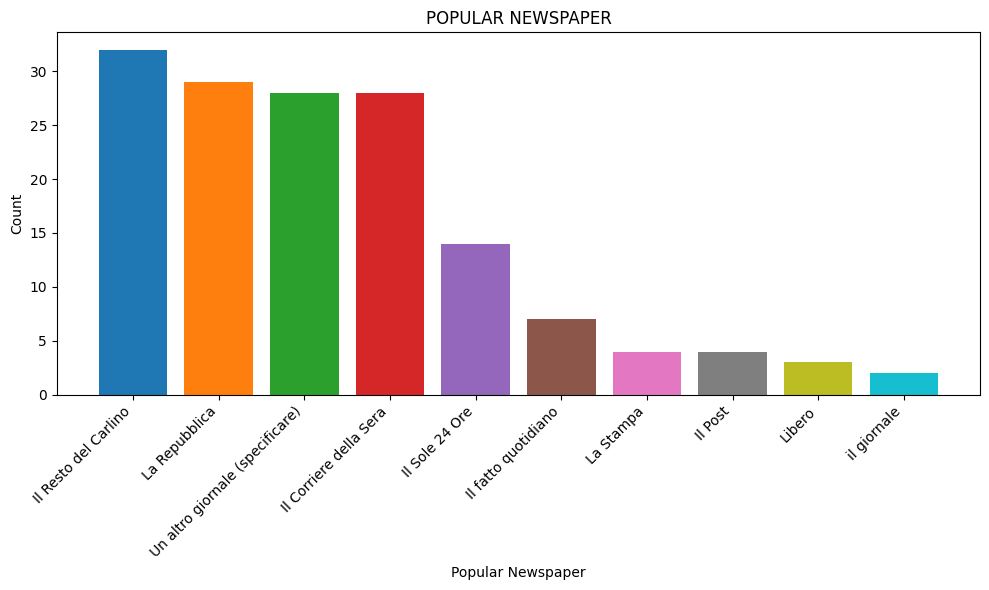

## Questions related to May 2023 Floods of Emilia-Romagna

This section of the questionnaire contains questions about the floods in Emilia-Romagna that occurred in May 2023. These questions cover various aspects, including the perceived causes of the floods and whether exposure to an extreme weather event, in this case a floods, led to any behavioral changes in respondents.

*Scroll down to see general questions related to May 2023 floods of Emilia-Romagna*

What do you think was the main cause of the May 2023 floods? (For now we are only referring to the root cause.)

```
    Q9 Quale pensa sia stata la causa principale delle inondazioni del Maggio 2023? (Per ora ci riferiamo solo alla causa principale.)

    *	Piogge intense
    *	Gestione errata del bacino del fiume (per esempio deforestazione e costruzione edilizia di massa)
    *	Gestione errata del livello de fiume fiume (include il funzionamento delle paratoie per mantenere il livello dell'acqua)
    *	Cambiamento climatico
    *	Altro motivo (specificare)
```

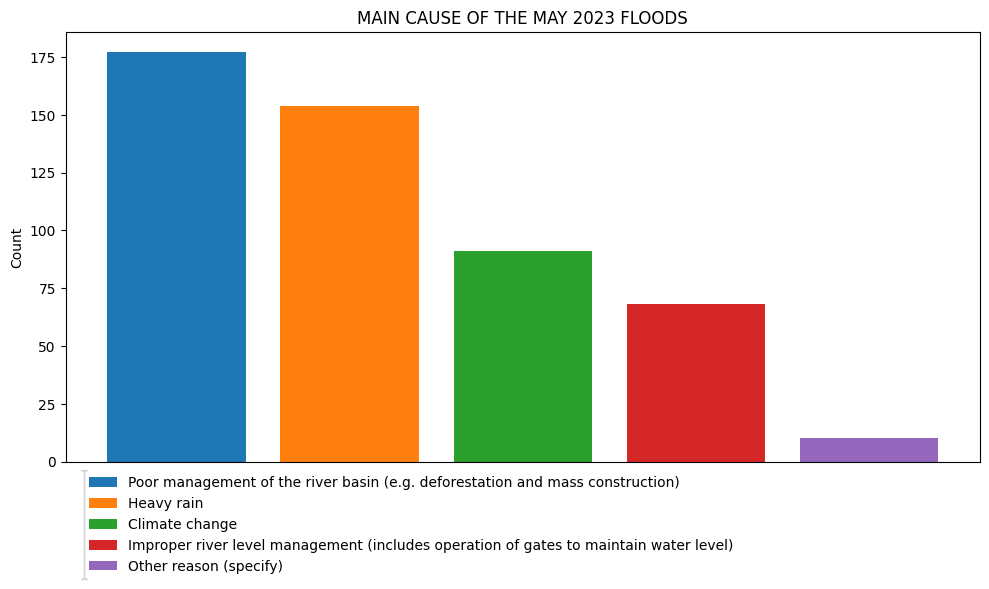

What do you think is the main reason for vulnerability to floods?

```
    Q10 Quale pensa sia la ragione principale della vulnerabilità alle alluvioni?

    *	Infrastrutture urbane inadeguate per il drenaggio
    *	Pratiche Agricole che influiscono negativamente sul drenaggio dell'acqua
    *	Assenza di un piano di emergenza completo per le comunità locali.
    *	Sistemi di monitoraggio fluviale e di allerta insufficienti
    *	Altro (specificare)
```

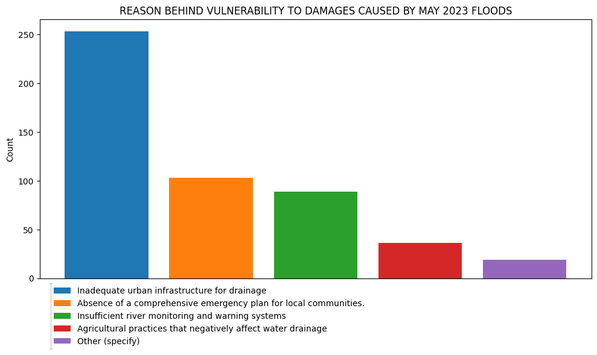

More than 50 percent of respondents attribute the vulnerability of Emilia-Romagna to damages caused during floods to inadequate urban drainage infrastructure. Approximately 100 and 89 respondents, respectively, identify the absence of a comprehensive emergency plan for local communities and insufficient river monitoring and water level warning systems as contributing significantly to the vulnerability to damages during floods. Finally, 36 respondents attribute vulnerability to flood damages to poor agricultural practices.

Q24 In che misura è d'accordo o in disaccordo con le seguenti affermazioni?

|  | Fortemente in disaccordo (1) | Abbastanza in disaccordo (2) | Né d'accordo né in disaccordo (3) | Abbastanza d'accordo (4) | Fortemente d'accordo (5) |
| --- | --- | --- | --- | --- | --- |
| Le alluvioni in Emilia Romagna mi hanno fatto riflettere sui cambiamenti climatici (1) | o | o | o | o | o |
| Sto cercando di ridurre il mio impatto ambientale dopo le alluvioni (2) | o | o | o | o | o |

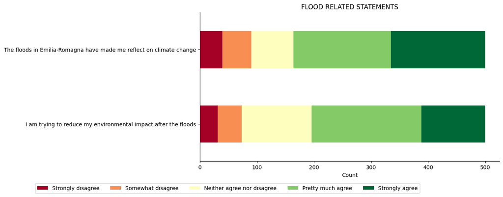

Which of the following actions have you taken to reduce your environmental impact (post floods)? Select all that apply.

[output not shown]

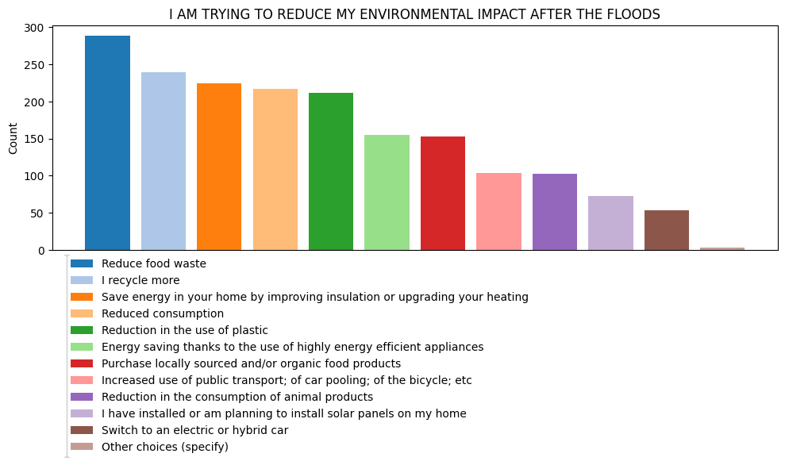

[figure not shown]

## Hero, Villain, and Victim

Following questions include questions regarding the causes of the floods, the responsible parties `Villain` for the damages, the extent of the damage, the affected parties `Victim`, the responsible entities for addressing these issues `Hero` and what they should do `Moral of the story`.

### Villain

Actors responsible for damages caused by flooding of Emilia-Romagna in May 2023 according to respondents.

Who do you think is responsible for the flood damage in Emilia-Romagna?

Drag the three most important ones and rank them in order of importance.

```
    Q12 Chi ritiene sia responsabile dei danni dell'alluvione in Emilia-Romagna?

    Trascina le tre piu'importanti e organizzale in ordine di importanza.

    * Il governo
    * La gestione locale del fiume
    * Gli agricoltori
    * Le aziende e imprese locali
    * Le ONG
    * Il cambiamento climatico
    * Altro (specificare)
```

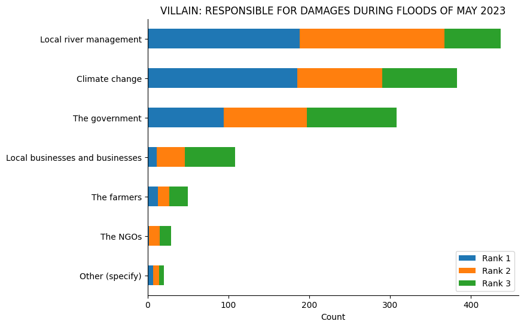

Which level of government is responsible for the flood damage in Emilia-Romagna?

```
    Q13 Quale livello di governo è responsabile dei danni dell'alluvione in Emilia-Romagna?

    *	Il governo nazionale
    *	Il governo regionale
    *	Gli enti locali
```

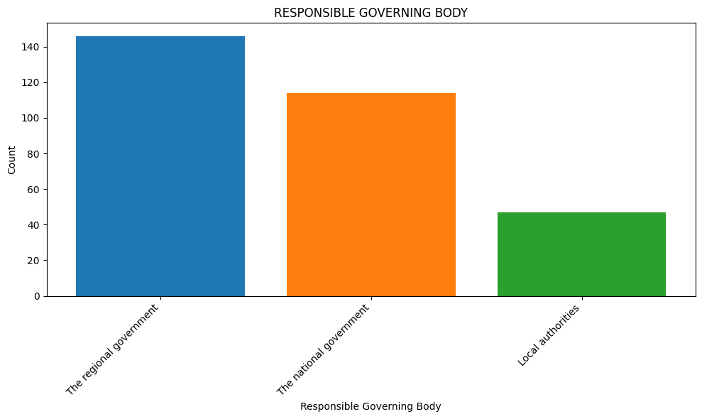

Who, according to your friends and colleagues, is held responsible for the damage caused by the floods in Emilia-Romagna?

Drag the three most important ones and arrange them in order of importance

```
    Q14 Chi, secondo i tuoi amici e colleghi, è ritenuto responsabile dei danni causati dalle inondazioni in Emilia-Romagna?

    Trascina le tre piu'importanti e organizzale in ordine di importanza.

    Trascina e organizza in ordine di classifica

    * Il governo
    * La gestione locale del fiume
    * Gli agricoltori
    * Le aziende e imprese locali
    * Le ONG
    * Il cambiamento climatico
    * Altro (specificare)
```

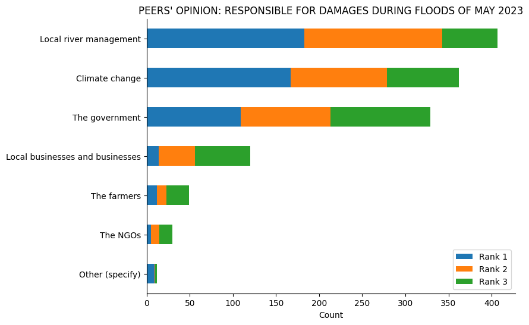

### Victim

Actors who suffered most damages caused by flooding of Emilia-Romagna in May 2023 according to respondents.

Which groups do you think were most affected by the floods?

Drag the three most important categories and organize them in order of relevance.

```
    Q17 Quali gruppi ritiene siano stati maggiormente colpiti dalle alluvioni?

    Trascina le tre categorie piu' importanti e organizzale in ordine di rilevanza.

    Trascina e organizza in ordine di classifica

    * I Residenti locali
    * Gli agricoltori e aziende agricole
    * Le aziende e imprese locali
    * Altri (specificare)
```

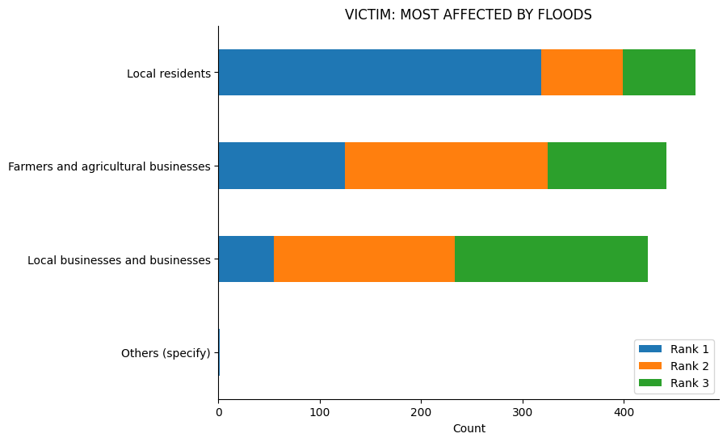

Which groups, according to your friends and colleagues, were most affected by the floods?

Drag the three most important ones and organize them in order of relevance.

```
    Q18 Quali gruppi, secondo i tuoi amici e colleghi, sono stati più colpiti dalle inondazioni?

    Trascina le tre piu'importanti e organizzale in ordine di rilevanza.

    Trascina e organizza in ordine di classifica

    * I Residenti locali
    * Gli agricoltori e aziende agricole
    * Le aziende e imprese locali
    * Altri (specificare)
```

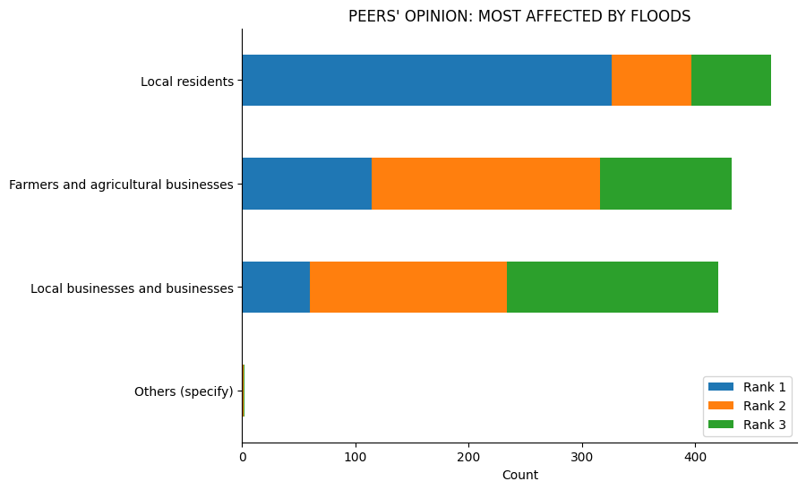

What do you think was most affected by the floods?

```
    Q16 Cosa ritiene sia stato maggiormente colpito dalle alluvioni?

    *	Case ed edifici
    *	L'ambiente, comprese le piante e gli animali
    *	Le infrastrutture critiche , comprese le strade e le linee elettriche
    *	Altro (specificare)
```

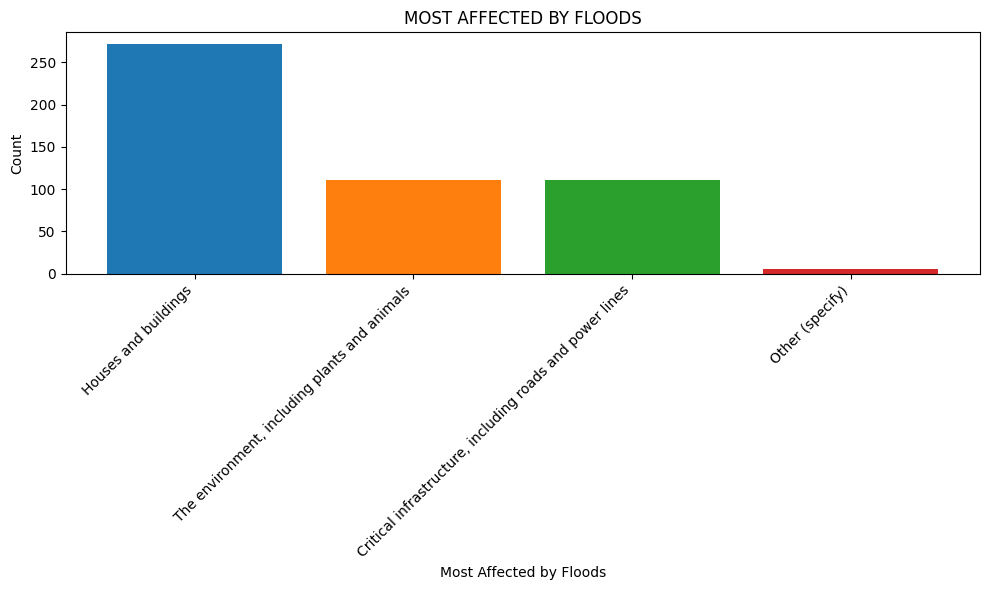

### Hero

Actors who should act to avoid future flood damages according to respondents.

Who should take the initiative to prevent future flood damage?

Drag the three most important ones and organize them in order of relevance

```
    Q20 Chi dovrebbe prendere l'iniziativa per prevenire futuri danni da alluvioni?

    Trascina le tre piu'importanti e organizzale in ordine di rilevanza.

    Trascina e organizza in ordine di classifica

    * Il governo
    * Le imprese locali
    * Le ONG
    * Gli agricoltori
    * La gestione locale del fiume
    * I residenti/ la popolazione locale
    * Altri (specificare)
```

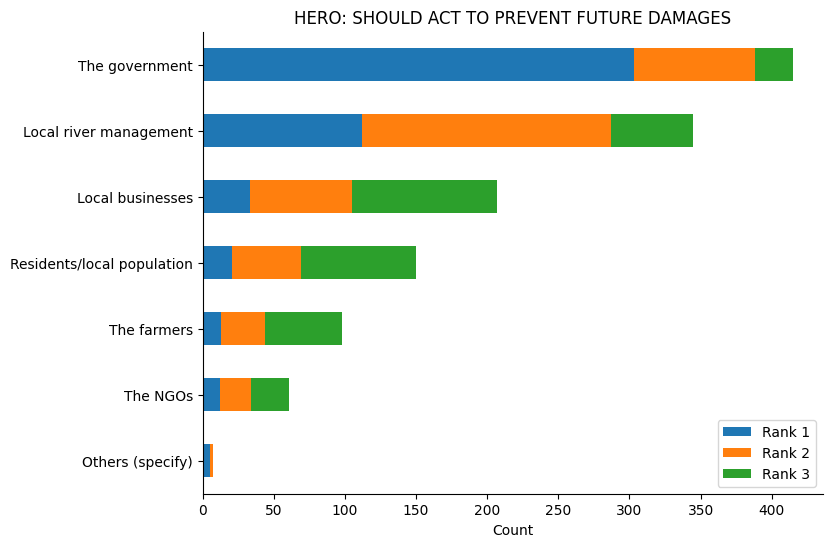

Which level of government should take the initiative to prevent future flood damage?

```
    Q21 Quale livello di governo dovrebbe prendere l'iniziativa perdi prevenire futuri danni da alluvione?

    *	Il governo nazionale
    *	Il governo regionale
    *	Gli enti locali
```

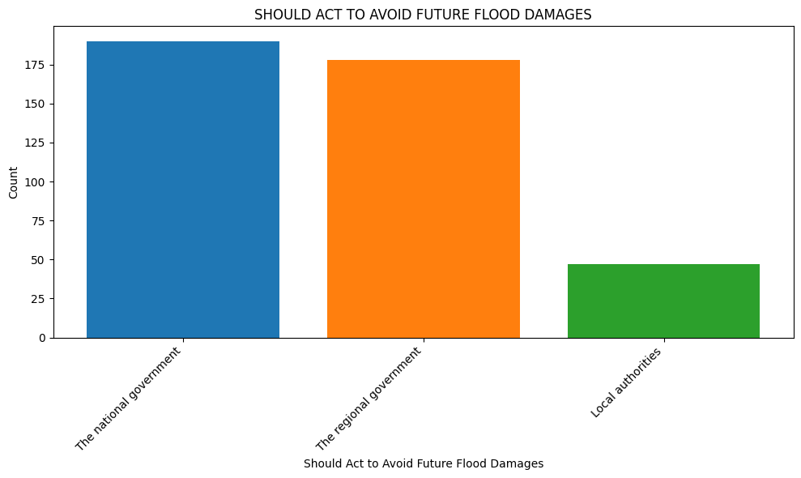

Who do your friends and colleagues say should take the lead in preventing potential damage from future floods?

Drag the three most important ones and organize them in order of relevance

```
    Q22 Chi, secondo i tuoi amici e colleghi, dovrebbe assumersi la guida nella prevenzione di potenziali danni da future inondazioni?

    Trascina le tre piu'importanti e organizzale in ordine di rilevanza.

    Trascina e organizza in ordine di classifica

    * Il governo
    * Le imprese locali
    * Le ONG
    * Gli agricoltori
    * La gestione locale del fiume
    * I residenti/ la popolazione locale
    * Altri (specificare)
```

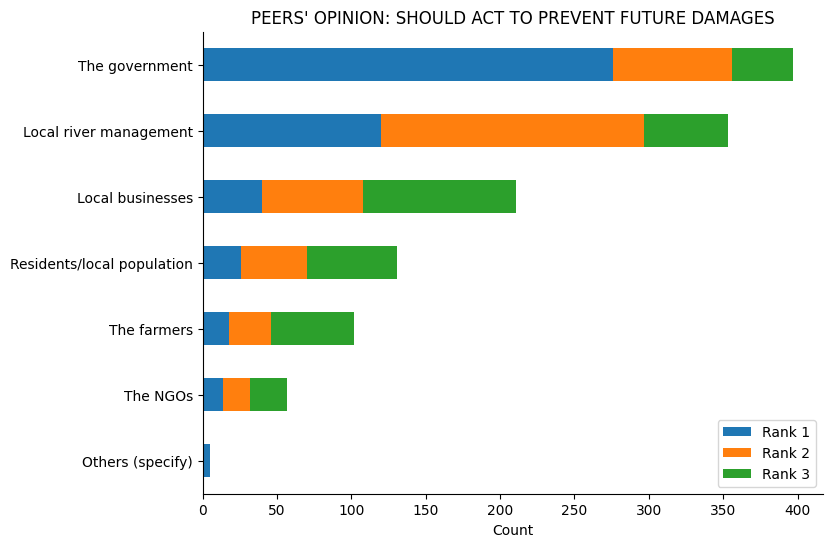

### Moral of the story: Policy Solution

Prefered policy solutions to prevent and prepare against future flood damages according to respondents.

What do you think should be done to prevent future flood damage?

```
    Q19 Cosa pensa si debba fare per prevenire futuri danni da alluvione?
```

|  | Sicuramente | Forse | Per niente |
| --- | --- | --- | --- |
| Migliorare le infrastrutture critiche | o | o | o |
| Uso sostenibile del territorio | o | o | o |
| Sistemi di allarme rapido | o | o | o |
| Coinvolgimento della comunità | o | o | o |
| Politiche governative | o | o | o |
| Tassare le industrie inquinanti | o | o | o |

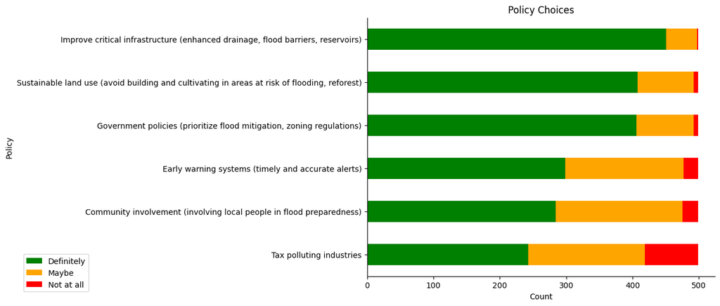